# Activity Data Analysis

Timothy M. Rodriguez

Sunday, February 08, 2015

## Getting the data

Here we download the data (if not already downloaded) and unzip it and report an overall summary of the data.

```r
file.name <- "activity"
file.name.zip <- paste(file.name, ".zip", sep="")
file.name.csv <- paste(file.name, ".csv", sep="")
if (!file.exists(file.name.zip)) {
    download.file("http://d396qusza40orc.cloudfront.net/repdata%2Fdata%2Factivity.zip", file.name.zip)
}
unzip(file.name.zip)
activity.data <- read.csv(file.name.csv)

summary(activity.data)
```

```
##      steps                date          interval
##  Min.   :  0.00   2012-10-01:  288   Min.   :   0.0
##  1st Qu.:  0.00   2012-10-02:  288   1st Qu.: 588.8
##  Median :  0.00   2012-10-03:  288   Median :1177.5
##  Mean   : 37.38   2012-10-04:  288   Mean   :1177.5
##  3rd Qu.: 12.00   2012-10-05:  288   3rd Qu.:1766.2
##  Max.   :806.00   2012-10-06:  288   Max.   :2355.0
##  NA's   :2304     (Other)   :15840
```

## Answering Questions

Next, we’d like to answer some questions about the data. For example

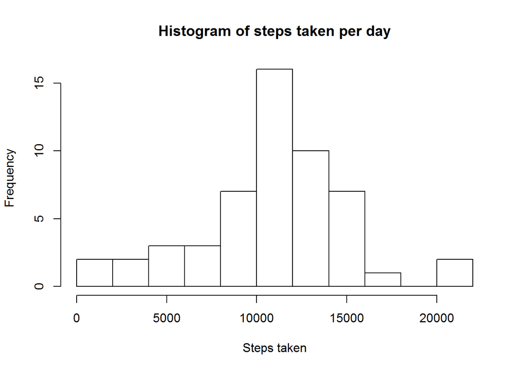

```r
hist(aggregate(steps ~ date, data=activity.data, sum)$steps,
     breaks=10,
     main="Histogram of steps taken per day",
     xlab="Steps taken")
```

```r
median <- median(activity.data$steps, na.rm=T)
mean <- mean(activity.data$steps, na.rm=T)
```

### 2. What is the average daily activity pattern?

Let’s aggregate the data by interval.

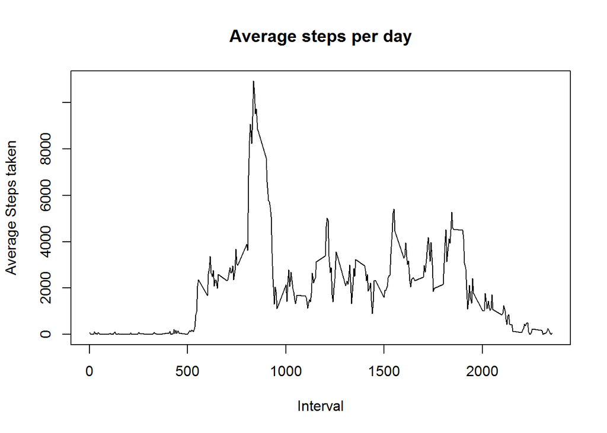

```r
steps.by.interval <- aggregate(steps ~ interval, data=activity.data, sum)
plot(steps.by.interval$interval,
     steps.by.interval$steps,
     type="l",
     main="Average steps per day",
     xlab="Interval",
     ylab="Average Steps taken")
```

```r
max.interval <- steps.by.interval[steps.by.interval$steps == max(steps.by.interval$steps), ]$interval
```

The 5-minute interval with the highest steps on average is 835.

There may be some bias being introduced by missing values.

```r
number.of.missing.rows <- nrow(activity.data[!complete.cases(activity.data), ])
```

The total number of missing values are 2304.

```r
get.mean.for.interval <- function(interval) {
    steps.by.interval[steps.by.interval$interval == interval, ]$steps
}
activity.data.no.nas <- data.frame(activity.data)
activity.data.no.nas$steps <- sapply(activity.data.no.nas$interval, get.mean.for.interval, simplify=T)
number.of.missing.rows.after.cleanup <- nrow(activity.data.no.nas[!complete.cases(activity.data.no.nas), ])
```

There are now 0 NAs after imputing values. Okay, let’s plot the cleaned up data.

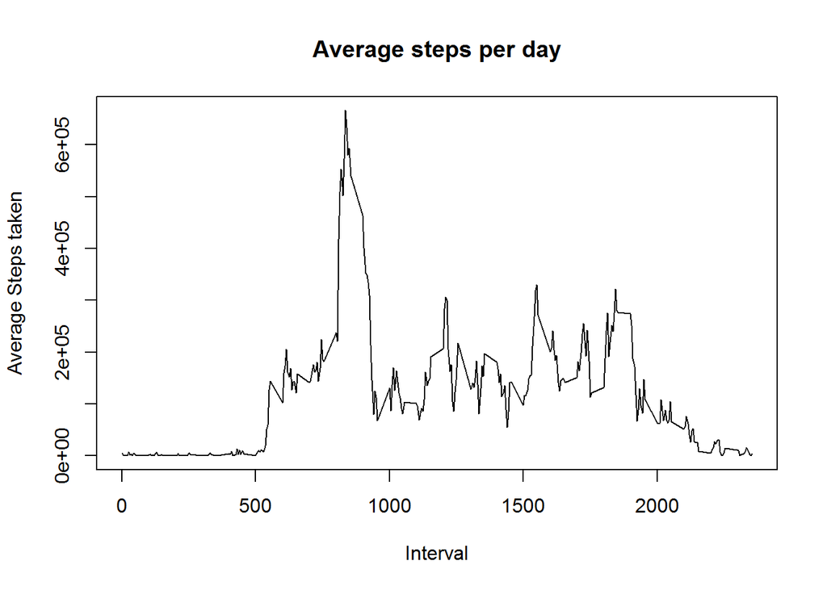

```r
steps.by.interval.no.nas <- aggregate(steps ~ interval, data=activity.data.no.nas, sum)
plot(steps.by.interval.no.nas$interval,
     steps.by.interval.no.nas$steps,
     type="l",
     main="Average steps per day",
     xlab="Interval",
     ylab="Average Steps taken")
```

### 3. Are there differences in activity patterns between weekdays and weekends?

Let’s label each observation with a factor for weekend or weekday.

```r
day.type <- factor(c("weekday", "weekend"))
get.day.type <- function(date) {
    day <- weekdays(as.Date(date))
    if (day == "Saturday" || day == "Sunday") {
        levels(day.type)[2]
    } else {
        levels(day.type)[1]
    }
}
activity.data.no.nas$day.type <- sapply(activity.data.no.nas$date, get.day.type, simplify=T)
```

Next, let’s aggregate the data by interval and day type.

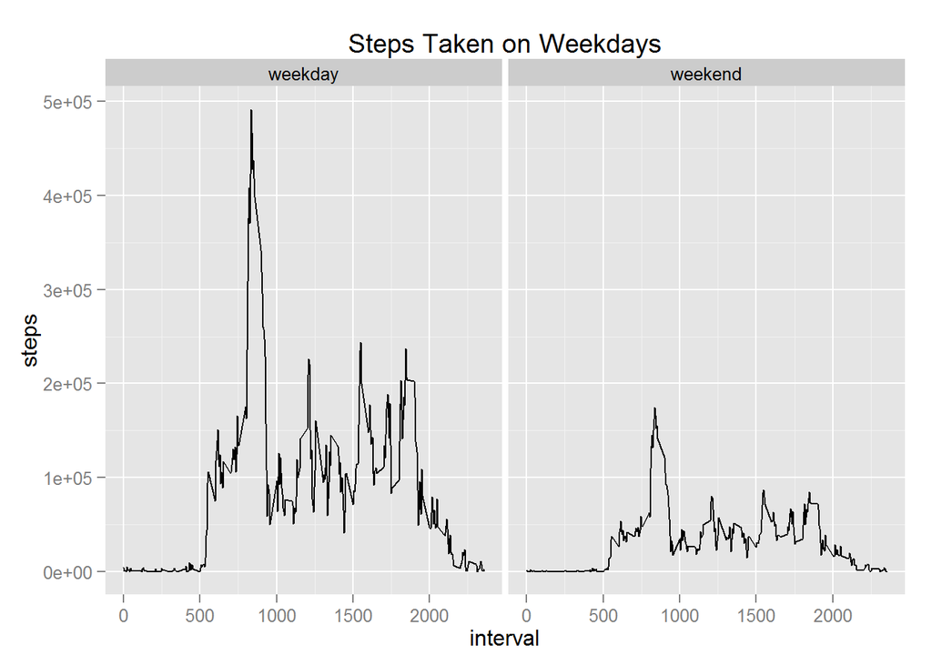

```r
steps.by.interval.and.day.type <- aggregate(steps ~ interval + day.type, data=activity.data.no.nas, sum)
library(ggplot2)
ggplot(steps.by.interval.and.day.type, aes(x=interval, y=steps, group="weekday")) +
    ggtitle("Steps Taken on Weekdays") +
    geom_line() +
    facet_wrap(~day.type)
```